# BankChurn Data Project / Yeoman Yoon

### Model Improvement:

### Model 2:

Little bit of parameter change. Increase in Neurons and iterations

```python
#Training Multi-layer perceptron with 2 hidden layers

#adding earlystopping callback
es= keras.callbacks.EarlyStopping(monitor='val_loss',
                              min_delta=0,
                              patience=15,

                             verbose=0, mode='min', restore_best_weights= True)

model2 = Sequential()
#Initializing the weights uisng hue_normal

model2.add(Dense(65, input_shape=(11, ), kernel_initializer='he_normal', activation='relu'))
model2.add(Dropout(0.5))
model2.add(Dense(65, kernel_initializer='he_normal', activation='relu'))
model2.add(Dropout(0.5))

model2.add(Dense(1, kernel_initializer='he_normal', activation='sigmoid')) # output

model2.compile(Adam(lr=0.001), loss='binary_crossentropy', metrics=['accuracy']) # learning rate of 0.001

his_mod2= model2.fit(X_train, y_train, validation_split=0.2, batch_size=1000, epochs=60,
                     callbacks=[es], shuffle=True, verbose=1)
```

```
Train on 5597 samples, validate on 1400 samples
```

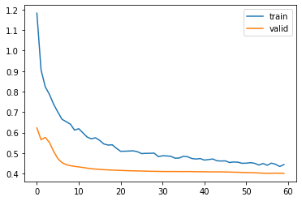

```python
# Learning history per epoch
hist  = pd.DataFrame(his_mod2.history)
hist['epoch'] = his_mod2.epoch

# Accuracy at different epochs
plt.plot(hist['loss'])
plt.plot(hist['val_loss'])
plt.legend(("train" , "valid") , loc =0)
```

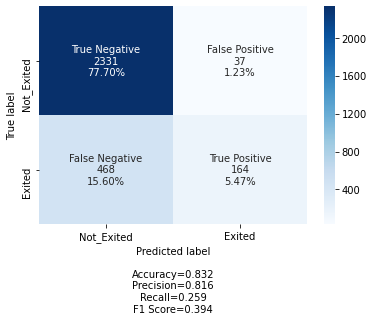

```python
y_pred1 = model2.predict(X_test)
for i in range(len(y_test)):
    if y_pred1[i]>0.5:
        y_pred1[i]=1
    else:
        y_pred1[i]=0



cm2=confusion_matrix(y_test, y_pred1)
labels = ['True Negative','False Positive','False Negative','True Positive']
categories = [ 'Not_Exited','Exited']
make_cm(cm2,
                      group_names=labels,
                      categories=categories,
                      cmap='Blues')
```

### Model 3:

Recall weighted model because of unbalanced data

```python
from warnings import simplefilter # prevents error cell below
simplefilter(action='ignore', category=FutureWarning)
```

```python
from sklearn.utils import class_weight
class_weights = class_weight.compute_class_weight('balanced', np.unique(y_train['Exited']), y_train['Exited'])
class_weights = dict(enumerate(class_weights))
class_weights
```

```
{0: 0.6256258941344778, 1: 2.490035587188612}
```

```python
from sklearn.utils import class_weight
model.fit(X_train,y_train,batch_size=15,epochs=10, class_weight=class_weights, shuffle=True)
```

```
<keras.callbacks.callbacks.History at 0x1c6317f88c8>
```

```python
score_weighted = model.evaluate(X_test, y_test)
```

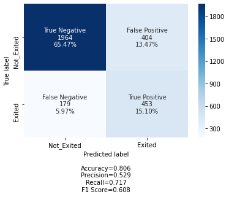

```python
y_pred1 = model.predict(X_test)
for i in range(len(y_test)):
    if y_pred1[i]>0.5:
        y_pred1[i]=1
    else:
        y_pred1[i]=0



cm2=confusion_matrix(y_test, y_pred1)
labels = ['True Negative','False Positive','False Negative','True Positive']
categories = [ 'Not_Exited','Exited']
make_cm(cm2,
                      group_names=labels,
                      categories=categories,
                      cmap='Blues')
```

### Overall:

1. Protect Age target of 35 to 55.
2. Non-active members are more likely to leave.
3. German are most likely to leave compared to French and Spanish
4. Customers with higher balnace are slightly more likely to leave.
5. Depending on the preference, Recall could be most significant.
6. Although data interpretation may not be smooth, Neural Network provides flexible models